# OHIBC Howe Sound: sponge and soft-bottom data prep

## 3.2 Sponge reef by protection status

This method of sponge reef habitat scoring will calculate the amount of sponge reef (based upon the georeferenced/polygonized raster provided by Karin Bodtker of CORI) is protected by sponge reef fishing closures (based upon the data from DFO).

By this method, and per discussion with Andrew Day and Karin Bodtker, the reference point should be 100% of sponge reef area protected by sponge reef closures.

| protected | area_prot_km2 | area_tot_km2 | status |
| --- | --- | --- | --- |
| protected | 0.2466 | 1.8198 | 0.1355094 |

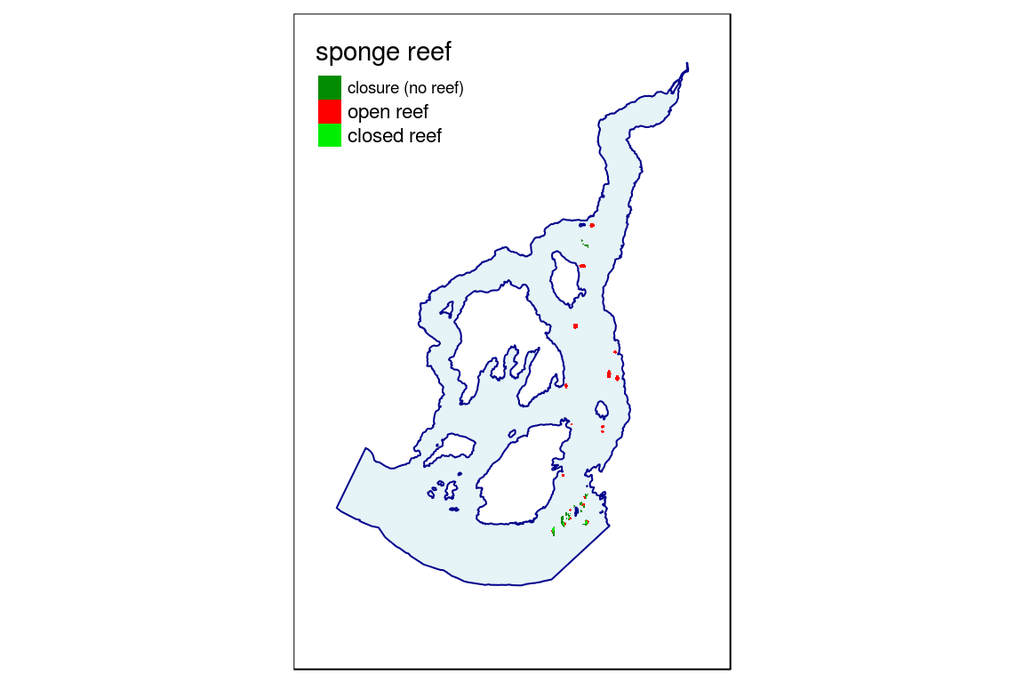

## 3.3 Soft-bottom habitat trawl pressures

Soft bottom habitat will be treated differently from sponges, as soft-bottom sediment is able to recover more quickly from trawling than sponges and other structure-forming habitats.

With the trawl effort on soft-bottom habitats by region, determine scores based on trawl effort (simple linear rescale). We would like to consider a non-linear method (e.g. log rescale) that amplifies the effects of small trawl effort relative to large trawl effort. This suggests that damage due to each additional unit of effort does not have the same ecological impact as those first few hours of trawling effort.

| area_tot_km2 | weighted_prs | hab_status |
| --- | --- | --- |
| 458.766 | 0.1565807 | 0.8434193 |

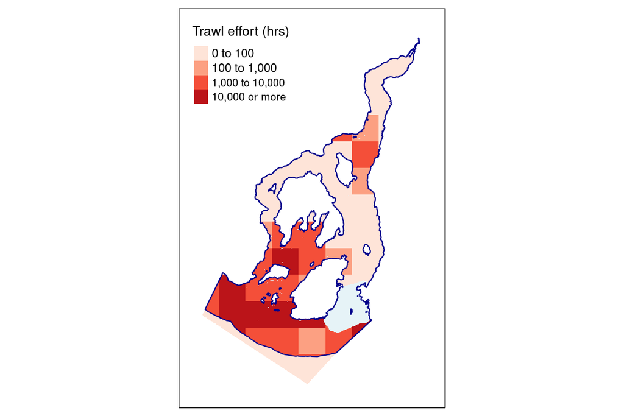

# 4 Provenance

- *Run ID: 12 (3c358b6); run tag: “standard run”*
- *Run elapsed time: 257.188 seconds; run memory usage: NA MB*
- *System info:*
  - *System: Linux, Release: 4.4.0-45-generic. Machine: x86_64. User: ohara.*
  - *R version: R version 3.3.2 (2016-10-31), Platform: x86_64-pc-linux-gnu, Running under: Ubuntu 14.04.5 LTS.*
  - *Attached base packages: stats, graphics, grDevices, utils, datasets, methods, base*
  - *Other attached packages: tmap_1.6-1, provRmd_0.1.1, stringr_1.1.0, dplyr_0.5.0, purrr_0.2.2, readr_1.0.0, tidyr_0.6.0, tibble_1.2, ggplot2_2.1.0, tidyverse_1.0.0, rgdal_1.1-10, raster_2.5-8, sp_1.2-3*

[figure not shown]

[output not shown]

[output cut: 45 more lines]